# Statistical Inference After Model Selection

Berk, Brown and Zhao (2010)

Abraham Iñiguez and Marwin Carmo

## Overview of the presentation

- Background & motivations
- Why is model selection an issue?
- Simulations of Model-Selection
- Summary
- Potential solutions

## Background & motivations

## Why is model selection an issue?

## Simulations of Model-Selection

$$\begin{equation}
y_i = \beta_0 + \beta_1w_i + \beta_2x_i + \beta_3z_i + \varepsilon_i
\end{equation}$$

### Fixed effects

- $\beta_0$ = 3.0
- $\beta_1$ = 0.0
- $\beta_2$ = 1.0
- $\beta_3$ = 2.0.

### Covariances

- $\sigma_{w,x}$ = 4.0
- $\sigma_{w,z}$ = 5.0
- $\sigma_{x,z}$ = 5.0

## Simulations of Model-Selection

```r
reps  <-  1000
p <- 3
Sigma <- matrix(c(5,4,5,
                  4,6,5,
                  5,5,7), p, p)
n <- 200
betas <- c(3, 0, 1, 2)

rsq <- NULL
coefs <- cover <- matrix(NA, nrow = reps, ncol = 3)
colnames(coefs) <- c("w", "x", "z")
colnames(cover) <- c("w", "x", "z")
```

## Simulations of Model-Selection

```r
reps  <-  1000
p <- 3
Sigma <- matrix(c(5,4,5,
                  4,6,5,
                  5,5,7), p, p)
n <- 200
betas <- c(3, 0, 1, 2)

rsq <- NULL
coefs <- cover <- matrix(NA, nrow = reps, ncol = 3)
colnames(coefs) <- c("w", "x", "z")
colnames(cover) <- c("w", "x", "z")

for (i in seq(reps)) {
  X <-  MASS::mvrnorm(n = n, rep(0, 3) , Sigma)
  y <- as.numeric(cbind(1, X) %*% betas + rnorm(n, 0, 10))
  Xy <- as.data.frame( cbind(X, y))
  colnames(Xy) <- c(c("w", "x", "z"), "y")
  fit <- lm(y ~., data = Xy)
  sel <- step(fit, k = 2, trace = FALSE)
  s <- summary(sel)
  tvals <- s$coefficients[,3][-1]
  coefs[i, names(tvals)] <-  tvals
  rsq[i] <- s$r.squared
}
```

|  | None | W | X | Z | WX | WZ | XZ | WXZ |
| --- | --- | --- | --- | --- | --- | --- | --- | --- |
| Berk et al. | 0 | 0 | 0.0001 | 17.4 | 1.0 | 4.9 | 65.7 | 10.8 |
| Replication | 0 | 0 | 0 | 17.6 | 0.9 | 3.7 | 66.2 | 11.6 |

### Statistics

[output not shown]

## t-values for $\beta_2$

- Red curve/ solid line = Conditional on preferred model being known
- Blue curve/ dashed line = Conditional on predictor being included in a model

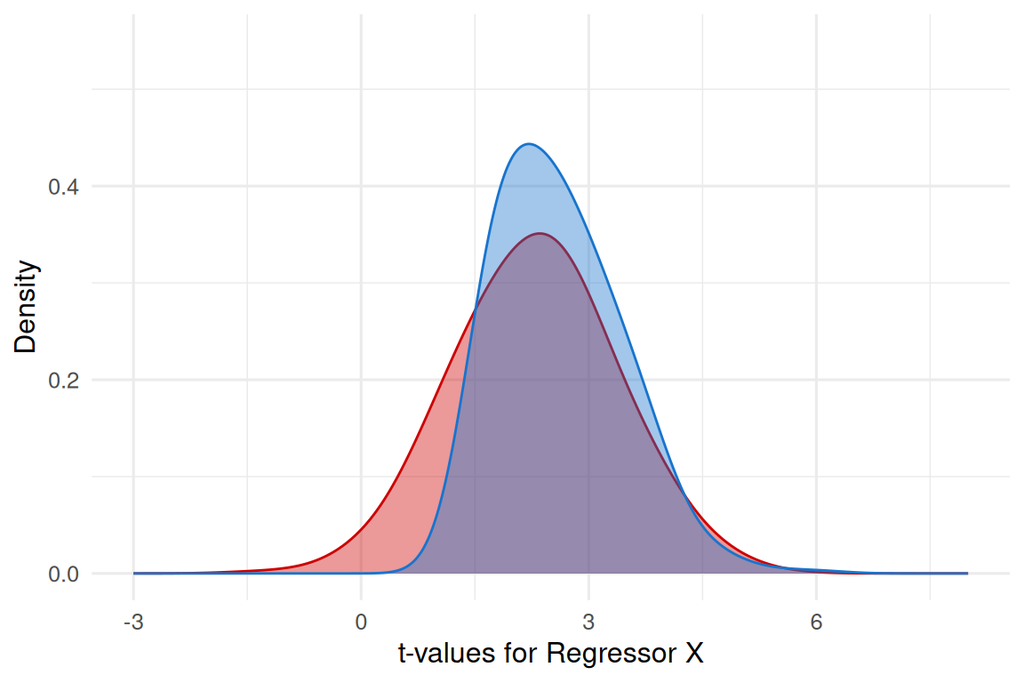

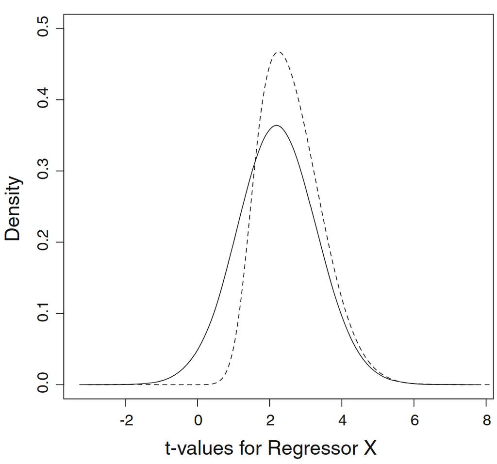

## t-values for $\beta_3$

- Red curve/ solid line = Conditional on preferred model being known
- Blue curve/ dashed line = Conditional on predictor being included in a model

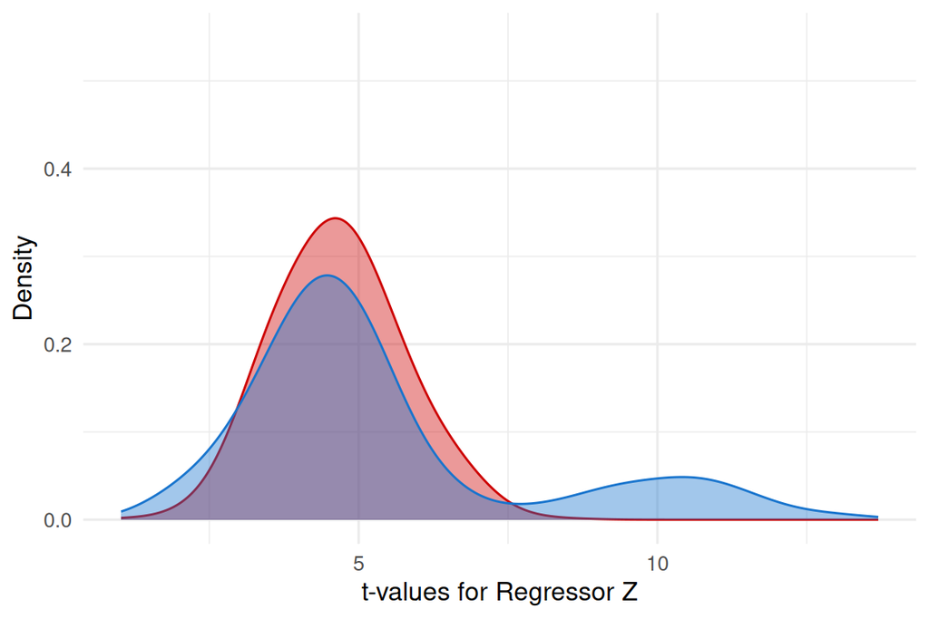

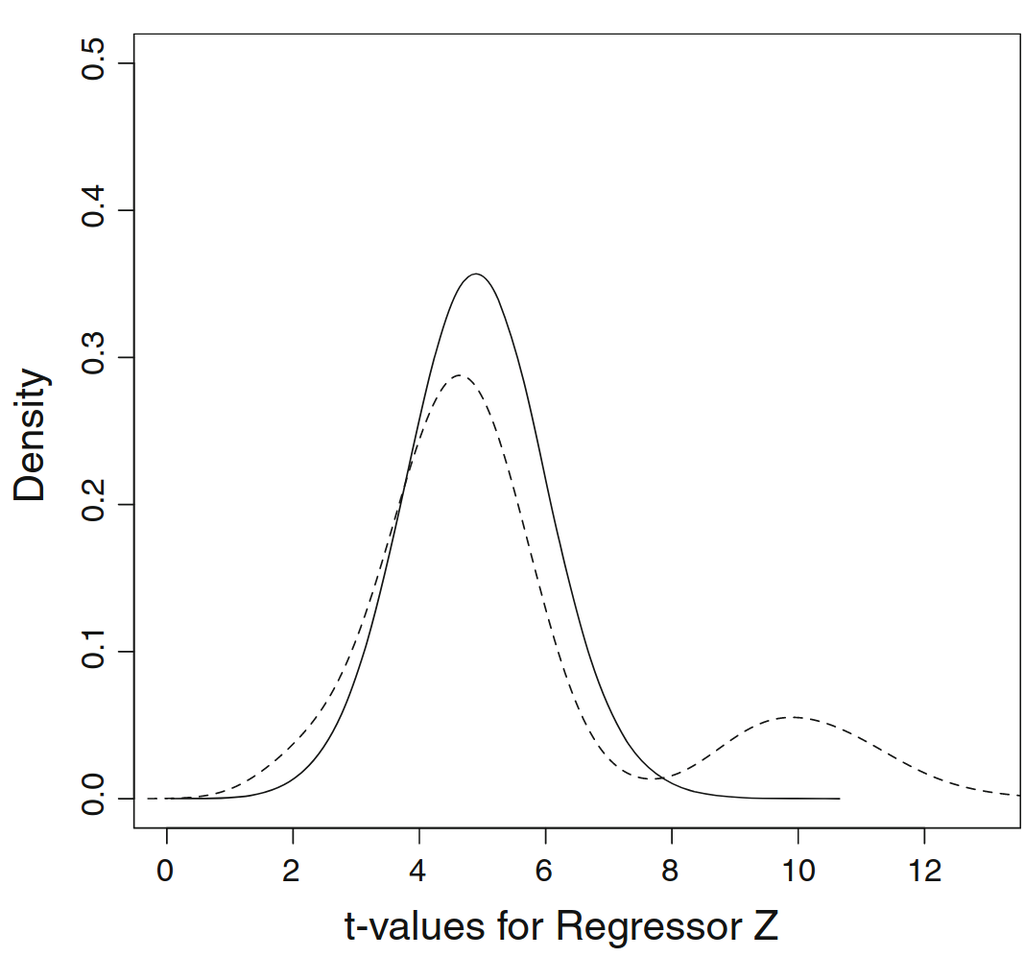

## False power

- For the preferred model, power to reject $H_0: \beta_2=0$ with $\alpha =0.05$ is approximately 60%.
- After model selection, that probability is about 76%.
- Bias due to model selection artificially inflates power in about 27%.
- Statistical inference might be problematic even when the statistical inference is conditional on arriving at the preferred model ($X$ and $Z$ included):

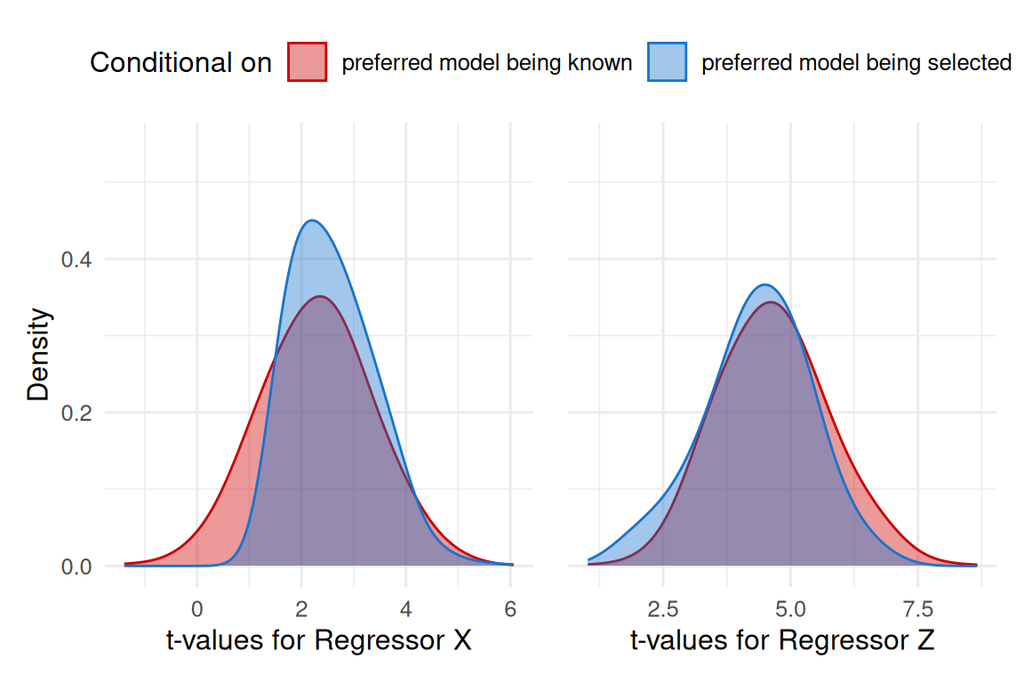

## Summary

- Post-model-selection statistical inference can lead to biased regression parameter estimates and seriously misleading statistical tests and confidence intervals.
- The particular selection procedure used does not materially matter.
- Sometimes the correct sampling distribution and the post-model-selection sampling distribution will be very similar.

## Potential solutions

- Split sample in training and test samples (😦)
- Collect two random samples (😨)
- Derive a theoretically based appropriate model (😰)
- Differentiate between confirmatory and exploratory analysis (🤯)
- Should all else fail, forego formal statistical inference altogether (☠️)
- Model averaging (Lukacs et al., 2019)[https://link.springer.com/article/10.1007/s10463-009-0234-4]

## Discussion

- What did the authors do particularly well?
- Simulation conditions were well specified
- Good framing of the problem and laying out potential solutions
- Is there enough detail that you could replicate their simulation given the information in the paper?
- As we have shown, there are!

## Discussion

Statistical Inference After Model Selection